# Interactive data visualization: D3

Mahbubul Majumder, PhD  
Oct 30, 2014

### What is D3 ?

- Data Driven Document
- JavaScript library provided by [Mike Bostock](http://bost.ocks.org/mike/)
  - functions to generate elegant web graphics
  - smooth transition, animation and allows interactivity with graphics
- Knowledge needed besides math/stat
  - HTML, CSS, JavaScript
  - Document Object Model (DOM) such as XML tree
  - Scalable Vector Graphics (SVG)
- It is intended for displaying facts already discovered by other tools like ggplot2
  - Read chapter 2 of Interactive data visualization for the web  
    http://chimera.labs.oreilly.com/books/1230000000345/ch02.html

### Basic building blocks

- SVG comes with a basic set of shape elements:
  - rectangle
  - circle
  - ellipse
  - straight Line
  - polyline
  - polygon
- D3 provides
  - automation
  - smooth transitions
  - interactivity

### Basic SVG shapes

- Drawing a rectangle

```r
<svg width="500" height="100">
  <rect x="200" y="0" width="150" height="100" fill="steelblue" />
</svg>
```

- Drawing a circle

```r
<svg width="500" height="100">
  <circle cx="270" cy="50" r="50" fill="purple" />
</svg>
```

- Drawing line

```r
<svg width="500" height="90">
  <line x1="50" y1="5" x2="400" y2="90" stroke="maroon" stroke-width="5"/> </svg>
```

- Drawing a polygon

```r
<svg width="500" height="80">
  <polygon fill="orange" stroke="blue" stroke-width="3" points="150,75 200,10 250,50"/> </svg>
```

### How D3 works

- Uses JavaScripts to change the attributes of the shapes
  - data are mapped to each of the attributes
  - many codes are automated, so you don't have to worry about details
  - for transitions, the attributes are changed with some delay
  - CSS helps to implement this in more controlled way
- D3 functionalities are loaded sourcing the D3 link. Basic HTML codes with D3 follow

```r
<!DOCTYPE html>
 <html>
   <head>
     <script type="text/javascript"
     src="http://d3js.org/d3.v3.min.js"> </script>
   </head>
   <body>
     <script>
       ... Your D3 codes go here ...
     </script>
   </body>
 </html>
```

### D3 methods and operators

- D3 methods; such as `select()`, `selectAll()`
  - need to use dot `.` followed by `D3` such as `D3.select()`
  - example `D3.select("body")` or `D3.selectAll("circle")`
- D3 operators; such as `append()`, `style()`, `data()`, `enter()`
  - need to use `.` followed by `D3` methods such as `D3.select().append()`
  - example `D3.select("body").append("svg")`
  - chain operation can be performed using successive dots `.`

```r
d3.select("svg").append("circle")
  .attr("cx",100).attr("cy",100)
  .attr("r",50)
  .style("fill", "steelblue")
```

### JavaScript console

- Modern browsers provide JavaScript console
  - allows testing the script on the fly
  - values of the variables can be obtained and manipulated
  - facilitates debugging
  - for Chrome, right click and then select inspect element

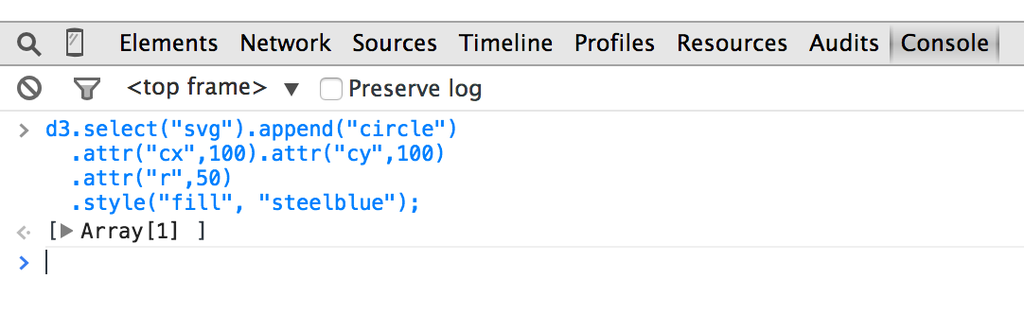

- You can test your codes in [jsfiddle](http://jsfiddle.net/) as well.

### Drawing a circle using D3

```r
<html>

 <head>
  <script type="text/javascript" src="http://d3js.org/d3.v3.min.js"></script>
 </head>

 <body>
 <h1>My circle</h1>
 <svg id="s1" width="200" height="200"></svg>

 <script>
  d3.select("#s1").append("circle")
    .attr("cx",100).attr("cy",100)
    .attr("r",50)
    .style("fill", "steelblue")
 </script>

 </body>
</html>
```

# My circle

### Mapping data to attributes

```r
<svg id="s2" width="900" height="200">
<script>
 var myDat = [50,100,150,200];
 d3.select("#s2").selectAll("circle")
   .data(myDat).enter().append("circle")
   .attr("cx",function(d){return(d);})
   .attr("cy",100).attr("r",20)
   .style("fill", "blue");
</script>
```

[figure not shown]